# BUA 455 - Week 13

Author

Penelope Pooler Eisenbies

Published

December 1, 2022

```r
# this line specifies options for default options for all R Chunks
knitr::opts_chunk$set(echo=T,
                      highlight=T)

# suppress scientific notation
options(scipen=100,
        getSymbols.warning4.0 = FALSE)

# install helper package (pacman), if needed
if (!require("pacman")) install.packages("pacman", repos = "http://lib.stat.cmu.edu/R/CRAN/")
# install and load required packages
# pacman should be first package in parentheses and then list others
pacman::p_load(pacman,tidyverse, knitr, gt, tidyquant)

# verify packages (comment out in finished documents)
p_loaded()
```

```
 [1] "tidyquant"            "quantmod"             "TTR"
 [4] "PerformanceAnalytics" "xts"                  "zoo"
 [7] "lubridate"            "timechange"           "gt"
[10] "knitr"                "forcats"              "stringr"
[13] "dplyr"                "purrr"                "readr"
[16] "tidyr"                "tibble"               "ggplot2"
[19] "tidyverse"            "pacman"
```

### Final Projects

#### **Presentations are next week, Tue. 12/6 and Thu. 12/8**

- If your group wants to present on Tue. 12/6, let me know by Thursday.
  - Otherwise, random order will be posted on Friday.
- Attendance required by all
- Dress: Business casual with emphasis on casual
- Suits, Ties, Dresses, and Jackets are **NOT** required
- No sweats t-shirts or pjs
- You will present better if you dress the part (at least a little)
- All students should be prepared to answer questions about the work presented.
- Each student will evaluate other groups and their own group members
- **All project components must be submitted by Tuesday, December 13th at 5:00 PM**

### Project Memos

- [Project Description - Memos are described on Page 5](https://docs.google.com/document/d/1U-DJ3yeHPpxcg1o12Cg2qc2Besb6Jw6UiyAo6gR4S2I/edit?usp=sharing)
- [Template for Memo to Supervisor](https://docs.google.com/document/d/1YG_tuwnx1TqUUDIyCT37dtMTi3cC7tbdjbus9zUEBqc/edit?usp=sharing)
  - Supervisor Memo’s Goal:
    - Provide your supervisor with what they need
    - They will want to be knowledgeable about the data and dashboard, but have very limited time.
    - Predict questions they (supervisor) might have and questions a client might ask.
- [Template for memo to Colleague](https://docs.google.com/document/d/14TceEQ-wr6ZF8WLdHQuFBUKuE8_6UiNsdrXS2O0lAEk/edit?usp=sharing)
  - Colleague Memo’s Goal:
    - Colleague should be able to follow memo to update dashboard quickly and seamlessly when new data are available.
    - I (or TAs) will follow memo and verify that instructions are clear, links are functional, and I can update dashboard based on this memo. when new data are available.

#### Questions about Project and Templates?

### R Markdown (.Rmd) and Quarto (.qmd) formats

- RStudio is currently in transition
- Documents can be rendered from R Markdown (.Rmd) or [Quarto (.qmd)](https://quarto.org/)
  - HTML, Word documents, PDf
  - R Markdown will be available for forseeable future
  - flexdashboard not available in Quarto format yet
    - [Options Currently Available in Quarto](https://quarto.org/docs/faq/rmarkdown.html)
- Presentations can be rendered from R Markdown (.Rmd) or Quart (.qmd)
  - Powerpoint
    - better for non-technical talks
  - Quarto Presentations (RevealJS) will replace Xaringan
    - These slides are Xaringan
    - Updated options will make better slides with more options
    - Xaringan and RevealJS are preferred for including code and output

### Best way to learn Quarto

- Examine Examples provided in R
- Examine Examples in [Quarto Gallery](https://quarto.org/docs/gallery/)
  - click on code symbol `</>` to see the code used to create the documents or presentations
  - Examine and modify code for your document
  - Also use Google, website documentation, and stack overflow for questions

### Resources - Where to go next

#### **For all aspects of analytics and R and RStudio**

- Discovered last semester: [Big Book of R - A Curated Website of R Resources](https://www.bigbookofr.com/index.html)
  - Updated November 2022
- Doesn’t include [text reference for this class](https://rafalab.GitHub.io/dsbook/) which is good.
- Best resource I have found is Google which often leads to [stack overflow](https://stackoverflow.com/)
  - Stack Overflow is helpful but you have to know enough code to be able to understand answers.

### Tutorials

- As SU Students you also have free access to [Linkedin Learning](https://linkedinlearning.syr.edu/)
  - Great tutorials in R, Python, SQL
  - Employers are likely to expect some familiarity with each.
  - R is most versatile and powerful
  - Employers may prefer Python, SQL, or another language/environment because that is what they know.
  - NOTE: Python, SQL, others can all be utilized through RStudio.
  - Different languages can be combined in one RMarkdown document in separate chunks.
- [DataCamp](https://www.datacamp.com/) - Not Free, but Excellent.
  - Provides certificates of completion
  - Published this excellent [document about data fluency](https://drive.google.com/file/d/1_VoM3D6tPftjZpXCnTL8SKYBlOM_4KjG/view?usp=sharing)
    - **Download this document and save it for when you have to apply for jobs and answer questions about your skillset.**
- Other companies are quickly developing tutorial training too (some are good)

### Sharing and Collaborating - GitHub vs. RPubs

- Last week I introduced you to Rpubs which is ideal from sharing a dashboard.
- Alternatively, you may have already come across `GitHub` in searching for files or a package.
  - Slides for this course are stored on GitHub
  - Required for files where data, code and text are maintained together as a project, referred to as a **repository** or **repo**.
  - Not required for finished dashboard.
- GitHub is an online code sharing and code development platform.
- Many R packages start as development code on GitHub and over time they are refined and published.

### More about GitHub

- Once you create free account, you can learn more about how it works in this [tutorial](https://docs.GitHub.com/en/get-started/quickstart/hello-world).
- Collaborative coding is common on GitHub but is a little more complex than working on a shared drive.
  - Developers of games, R packages, other software, etc., have huge code files and need to protect them.
  - There is a system in place (version control) where people can create a project with multiple code versions and edits. Over time a project develops more and more branches, like a tree, but the trunk.
  - Original code is preserved and changes can be incorporated as they are verified and approved.

### Some GitHub links

- Some tutorial links for collaborative coding on GitHub:
  - [What is Git and GitHub? And how to use GitHub?](https://medium.com/@ravirajsubramanian/what-is-git-and-GitHub-and-how-to-use-GitHub-f49d6be08b25)
  - [How to use Git and GitHub for collaborative programming?](https://medium.com/@ravirajsubramanian/how-to-use-git-and-GitHub-for-collaborative-programming-955da6876aa9)
  - [Using Git and Github on Group Projects](https://medium.com/@androidmatheny/using-git-and-GitHub-on-group-projects-d636be2cdd4d)
  - [Section 33 of Big Book of R](https://www.bigbookofr.com/version-control.html)

### Evaluations

- Course Evaluations are very important.
- Please take the time to fill out evaluations.
  - [You can login to the Course Evaluations website here](http://coursefeedback.syr.edu/)
    - netID and password are required
  - I will step out for 5 minutes.

[figure not shown]

Course Evaluation QR Code

## Material Added on Wednesday 11/30

### Plan for today

- Address some submitted questions about Quarto and R Markdown
- Tips for a Better Dashboard
- Tables with GT
- Five (more) minutes for evaluations
- In-class work time

### Tips for a Better Dashboard

A good rule for this project (every project):

*Edit yourself*

- You may have a lot to say and show, **BUT** always consider:
  - **What can you present WELL in the space an time you have?**
- An important skill to develop is the ability to filter the data to a representative subset, especially for a visualization.
- Think about what data can be presented well and what the audience can digest.
- Don’t try to show too much in any one plot or panel.
- You can always show other parts of the data by
  - creating more panels
  - creating multi-plot grids to show other part of the data

### Tips for a Better Dashboard

At each stage of the process, take a step back and examine each dashboard panel as if you are seeing it with fresh eyes.

- As you do that, as yourself these questions:
- Does this panel achieve a specific goal?
- Is the point of this panel clear?
- If not, how can I edit or augment this panel to clarify what it is showing?
- Are the text and symbols readable from any distance?
- What can I simplify to make it more clear?
  - Are there aspects I think are important that might not be obvious?
  - If so, how can I modify the panel or dashboard to highlight the key aspects?
- When in doubt, ask someone like a roommate to look it and ask if they understand what you hope to convey.

### Tables in Dashboards and Documents

- This course focuses mostly on data visualizations, with a few table summaries.
- Creating a more complex table, may be useful to you and could be included as an additional main panel in your dashboard instead of side panel.
  - Not required, but it may be helpful.
- Even if you don’t use `gt` tables in your dashboard, they will definitely be helpful if you use R and RStudio to manage, analyze, and document data in the future.
- If you have not already done so, please rerun the setup for this lecture, which now includes the `gt` package and the package.
- The [`gt` website](https://gt.rstudio.com/index.html) has many examples with detailed step by step instructions.
- Notes about examples on `gt` website:
  - Examples use the older pipe notation `%>%` which is identical in function to `|>`.
  - Examples also use different commands to complete the same data management tasks covered in BUA 455.
  - If you are unsure about a command you come across ask me, or google it. The R help index is also good.
    - e.g. `?glue` or `?glue::glue` is the glue command in glue package

### Tables in Dashboards and Documents

First let’s look at what can be customized:

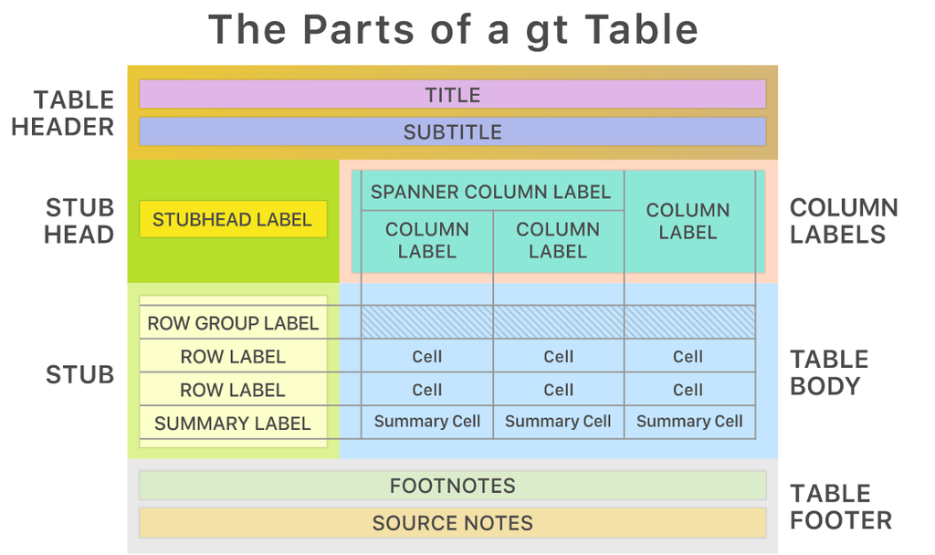

### Example: Importing, Summarizing and Displaying Stock Data

```r
getSymbols("^GSPC", from="2022-01-01", to="2022-11-01")
```

```
[1] "^GSPC"
```

```r
snp22 <- GSPC |>
  fortify.zoo() |> as_tibble(.name_repair = "minimal") |>
  rename("date" = "Index") |>
  mutate(mnth=month(date))|>
  group_by(mnth) |>
  filter(date==max(date)) |>  # filtered data to last day of each month
  ungroup() |>
  select(-c(6,8))    # remove volume and month variables
names(snp22)[2:6] <- c("Open", "High", "Low", "Close", "Adjusted")
head(snp22,3)
```

```
# A tibble: 3 × 6
  date        Open  High   Low Close Adjusted
  <date>     <dbl> <dbl> <dbl> <dbl>    <dbl>
1 2022-01-31 4432. 4517. 4414. 4516.    4516.
2 2022-02-28 4354. 4389. 4315. 4374.    4374.
3 2022-03-31 4599. 4603. 4530. 4530.    4530.
```

### Example: Importing, Summarizing and Displaying Stock Data

- The code below does not make a new tibble or data frame
- Instead it create a formatted table object that can be output as a .png file like a plot.
  - `kable` also creates a formatted table object, but `gt` has more features.
- As with plots, I am saving this object and then displaying it afterwards.

```r
snp_fmt <- snp22 |>
  gt(rowname_col = "date") |>
  tab_header(title = "S&P 500",
             subtitle = "Last Day of Each Month in 2022") |>
  tab_stubhead(label = "Date") |>
  fmt_date(columns=date, date_style=3) |>  # formats date
  fmt_currency(columns=Open:Adjusted, currency = "USD")|>     # formats values as US$
  tab_footnote("Data Source: https://finance.yahoo.com") |>
  tab_footnote("Symbol: ^GSPC")
```

In a dashboard or document, the code would be hidden, but it is shown here:

```r
snp_fmt         # code to display created table
```

S&P 500

Last Day of Each Month in 2022

| Date | Open | High | Low | Close | Adjusted |
| --- | --- | --- | --- | --- | --- |
| Mon, Jan 31, 2022 | $4,431.79 | $4,516.89 | $4,414.02 | $4,515.55 | $4,515.55 |
| Mon, Feb 28, 2022 | $4,354.17 | $4,388.84 | $4,315.12 | $4,373.94 | $4,373.94 |
| Thu, Mar 31, 2022 | $4,599.02 | $4,603.07 | $4,530.41 | $4,530.41 | $4,530.41 |
| Fri, Apr 29, 2022 | $4,253.75 | $4,269.68 | $4,124.28 | $4,131.93 | $4,131.93 |
| Tue, May 31, 2022 | $4,151.09 | $4,168.34 | $4,104.88 | $4,132.15 | $4,132.15 |
| Thu, Jun 30, 2022 | $3,785.99 | $3,818.99 | $3,738.67 | $3,785.38 | $3,785.38 |
| Fri, Jul 29, 2022 | $4,087.33 | $4,140.15 | $4,079.22 | $4,130.29 | $4,130.29 |
| Wed, Aug 31, 2022 | $4,000.67 | $4,015.37 | $3,954.53 | $3,955.00 | $3,955.00 |
| Fri, Sep 30, 2022 | $3,633.48 | $3,671.44 | $3,584.13 | $3,585.62 | $3,585.62 |
| Mon, Oct 31, 2022 | $3,881.85 | $3,893.73 | $3,863.18 | $3,871.98 | $3,871.98 |

Data Source: https://finance.yahoo.com  
Symbol: ^GSPC

### Editing a Table for a Presentation

- A table in dashboard side panel should be small.
- Previous table would not fit, but we can select variables and shorten the date.
- Limit the table to key variables that highlight important characteristics of your data.
- Other variables, e.g. `Open`, `Low`, can be shown in plot

```r
(snp_sm <- snp22 |>
select(1,3,6) |>
  gt(rowname_col = "date") |>
  tab_header(title = "S&P 500",
             subtitle = "2022 - Last Day of Each Month") |>
  tab_stubhead(label = "Date") |>
  fmt_date(columns=date, date_style=6) |>
  fmt_currency(columns=High:Adjusted,
               currency = "USD")|>
  tab_footnote("Source: https://finance.yahoo.com") |>
  tab_footnote("Symbol: ^GSPC"))
```

S&P 500

2022 - Last Day of Each Month

| Date | High | Adjusted |
| --- | --- | --- |
| Jan 31, 2022 | $4,516.89 | $4,515.55 |
| Feb 28, 2022 | $4,388.84 | $4,373.94 |
| Mar 31, 2022 | $4,603.07 | $4,530.41 |
| Apr 29, 2022 | $4,269.68 | $4,131.93 |
| May 31, 2022 | $4,168.34 | $4,132.15 |
| Jun 30, 2022 | $3,818.99 | $3,785.38 |
| Jul 29, 2022 | $4,140.15 | $4,130.29 |
| Aug 31, 2022 | $4,015.37 | $3,955.00 |
| Sep 30, 2022 | $3,671.44 | $3,585.62 |
| Oct 31, 2022 | $3,893.73 | $3,871.98 |

Source: https://finance.yahoo.com  
Symbol: ^GSPC

### **Key Points from Week 13**

- **Project Info**
  - Two Memos - Information, Templates, & Examples provided
- **Taking advantage of RStudio**
  - R Markdown and Quarto
    - Data management and reporting are seamless.
    - Can combine R chunks with PYthon, SQL etc.
- **Github and Rpubs**
  - For large projects, Github is essential
  - For BUA 455, Rpubs is ideal
- **Links for Learning More**
- **Data Camp White Paper about Skillset**

**You may submit an ‘Engagement Question or Comment’ about Week 13 lectures until Thursday, 12/1, at midnight on Blackboard.**